# knitr::spin – A more dynamic approach to dynamic documents

30 October 2019

## knitr::spin – Part I: The Basics

## Dynamic Documents

- Common Workflows:
  - .Rnw –> .tex –> .pdf
  - .Rmd –> .(md|tex) –> .(html|pdf|docx)
- These workflows are very good and should be used as much as possible.
  1. Write a document in a markup language, e.g., LaTeX, markdown, …
  2. Weave into the markup language an analysis language, e.g., R
  3. Create a deliverable dynamic and reproducible report
- Simple Example: 00-flights.Rmd to 00-flights.html

```r
rmarkdown::render(input = "00-flights.Rmd", output_format = "html_document")
```

[interactive chart not shown]

## Let's think about the paradigm

- Dynamic Document:
  - Implicit documentation, limit transcription errors, …
  - The *markup language* is the *primary* language for the file
  - The analysis language is weaved *into* a markup language
- I am a data analyst:
  - The *analysis language* is my *primary* language
  - The markup language is for extremely detailed comments
- Can you re-use the code? Can you source a .Rmd file?

```r
source("00-flights.Rmd")
## Error in source("00-flights.Rmd"): attempt to use zero-length variable name
```

## knitr::spin - Reverse the paradigm

- `knitr::spin`  
  https://yihui.name/knitr/demo/stitch/
  - R is the primary language
  - A markup language is the guest language
- Workflow: .R → .Rmd → .md → .html  
  That is,
  1. *spin* .R to .R(md|nw),
  2. *knit* to .(md|tex),
  3. and then build .(docx|html|pdf) via pandoc
- Example: 01-flights.R

```r
knitr::spin(hair = "01-flights.R", knit = FALSE)
# [1] "01-flights.Rmd"
rmarkdown::render(input = "01-flights.Rmd", output_format = "html_document")
```

[interactive chart not shown]

## Syntax

.Rmd

[interactive chart not shown]

.Rnw

[interactive chart not shown]

.R

[interactive chart not shown]

## knitr::spin

### Benefits

- R scripts!
  - Can be sourced by other scripts
  - Reuse your code!
- Multiple types of comments:
  - Standard R comments
  - Commented blocks omitted from resulting .R(md|nw|html|.+)
- My opinion:
  - easier development work to write a .R than a .Rmd
  - .Rmd is a redo of the original work done in "sandbox" files such as "eda.R" and "initial-analysis.R"

## The .R file

[interactive chart not shown]

```r
knitr::spin(hair = "02-flights.R", knit = FALSE)
# [1] "02-flights.Rmd"
rmarkdown::render(input = "02-flights.Rmd", output_format = "all")
```

## The .html

[interactive chart not shown]

## The .docx

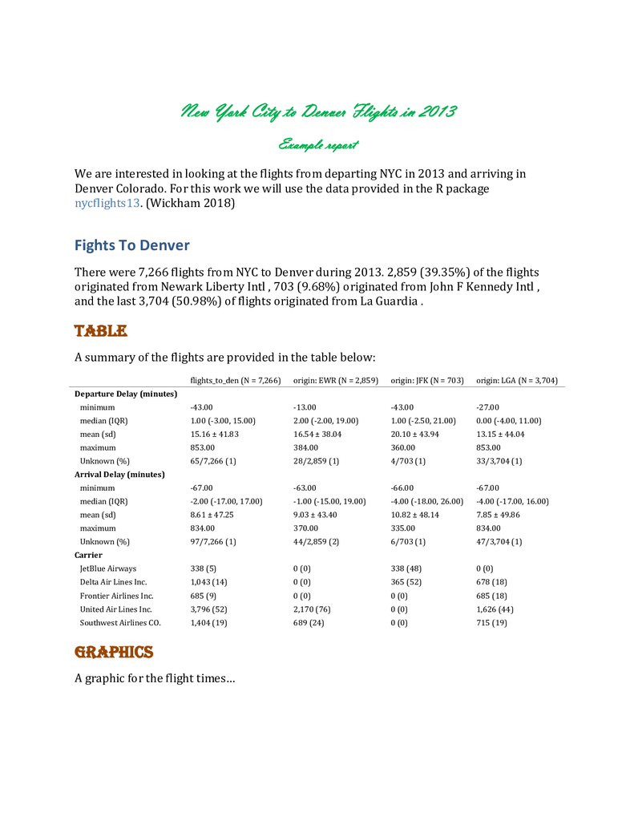

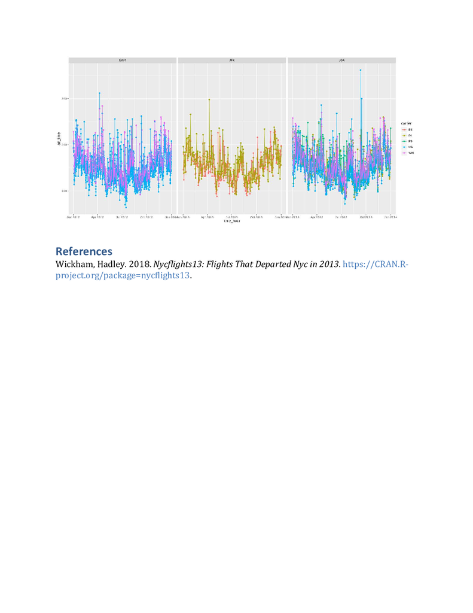

## knitr::spin

### Conditional Evaluation

- You have one .R file. It will be evaluated in two ways:
  1. As an R script in working directory A
  2. Spun to .Rmd and the Rmd will be evalauted as package vignette, or other document, evaluated from wroking directory B.
- Specific example: Building an R package "<pkg.name>"
  1. The R script evaluates as a script in the data-raw directory
  2. Spun to .Rmd for building a vignette

What does the following do?

## knitr::spin

### Conditional Evaluation

[interactive chart not shown]

## Thank you

- You are welcome to contact me with questions
  - peter.dewitt@cuanschutz.edu
- Slides and examples from this talk are available at
  - https://github.com/dewittpe/spin-seminar-20191030

[figure not shown]

- Want to meet other R Users from academics and industry? Come to a Denver R Users Group Meetup.
  - https://www.meetup.com/DenverRUG/